# Danish diabetes data

diabetes

data exploration

joins

survival analysis

Author

Henrik Vitus Bering Laursen

Published

June 17, 2025

## 1 Purpose

I remember using the `Epi::steno2` data-sets when taking a short course on multistate survival analysis with the creator of the package, [Bendix Carstensen](https://bendixcarstensen.com/).

That was quite fun but also daunting to be sitting in a room full of mathematicians and people who actually knew the nitty gritty of survival analysis and the math behind it.

I think I would just want to do something very basic here, though:

- 1. Playing around with joining the different data-sets
- 2. Examine the data-sets and visualize the contents
- 3. Creating a simple Cox Proportional Hazards model, comparing the risk of cardiovascular event between the two treatment groups in the data-set
  - Probably also controlling for some important factors
- 4. Deliver some sort of conclusion about these data

So lets start looking at it!

## 2 Load

The data-sets can be loaded directly from the `Epi` library, through `data()`

```r
data("steno2")
data("st2clin")
data("st2alb")
```

Alrighty now that they are loaded lets look at their structure. **Ofcourse, I am completely ignoring the description in the documentation in the `Epi()` package, which describes how the data-sets are structured.**

```r
str(steno2)
```

```
'data.frame':   160 obs. of  14 variables:
 $ id      : num  1 2 3 4 5 6 7 8 9 10 ...
 $ allo    : Factor w/ 2 levels "Int","Conv": 1 1 2 2 2 2 2 1 1 1 ...
 $ sex     : Factor w/ 2 levels "F","M": 2 2 2 2 2 2 1 2 2 2 ...
 $ baseCVD : num  0 0 0 0 0 1 0 0 0 0 ...
 $ deathCVD: num  0 0 0 0 1 0 0 0 1 0 ...
 $ doBth   : Date, format: "1932-04-11" "1946-11-09" ...
 $ doDM    : Date, format: "1991-01-21" "1982-01-30" ...
 $ doBase  : Date, format: "1993-04-30" "1993-06-08" ...
 $ doCVD1  : Date, format: "2014-05-24" "2009-03-15" ...
 $ doCVD2  : Date, format: NA "2009-07-02" ...
 $ doCVD3  : Date, format: NA "2010-02-16" ...
 $ doESRD  : Date, format: "NaN" "NaN" ...
 $ doEnd   : Date, format: "2014-10-12" "2014-08-04" ...
 $ doDth   : Date, format: NA NA ...
```

```r
str(st2clin)
```

```
'data.frame':   750 obs. of  5 variables:
 $ id  : num  1 2 3 4 5 6 7 8 9 10 ...
 $ doV : Date, format: "1993-05-07" "1993-05-05" ...
 $ a1c : num  87.3 66.5 73 61.2 102.7 ...
 $ chol: num  3.9 6.6 5.6 5.2 6 4.8 8.6 5.1 4.2 5.4 ...
 $ crea: num  83 83 68 97 149 55 56 78 123 79 ...
```

```r
str(st2alb)
```

```
'data.frame':   563 obs. of  3 variables:
 $ id   : num  1 1 1 1 1 2 2 2 2 2 ...
 $ doTr : Date, format: "1993-06-12" "1995-05-13" ...
 $ state: Factor w/ 3 levels "Norm","Mic","Mac": 2 1 2 1 2 1 2 3 2 2 ...
```

It looks like `steno2` and `st2clin` are one row per subject, and `st2alb` is multiple, but that doesn’t make sense given the amount of rows. We can see how many id’s, the unique identifier for each person, are present, and if there is one row per subject it should be close to the amount of subjects.

```r
# create a 1 for each time there is an ID
id_test1 <- steno2 |> count(id)
head(id_test1)
```

```
  id n
1  1 1
2  2 1
3  3 1
4  4 1
5  5 1
6  6 1
```

```r
# different numbers on those counts
id_test2 <- id_test1 |>  summarize(n=sum(n), idcount = max(id), sum = sum(id))
id_test2
```

```
    n idcount   sum
1 160     176 13650
```

Alright. So it is clear that only `steno2` has one row per subject because the number of id’s that occur equal the number of unique rows.

Lets see about the others

```r
st2alb |> count(id) |> summarize(n=sum(n), idcount = max(id), sum = sum(id))
```

```
    n idcount   sum
1 563     176 13187
```

```r
st2clin |> count(id) |> summarize(n=sum(n), idcount = max(id), sum = sum(id))
```

```
    n idcount   sum
1 750     176 13650
```

Ok so the `st2*` datasets have more than one row per subject, but there is a strange lower sum in `st2alb` than the other datasets.

Could it be that there are missing subjects in that dataset?

### 2.1 A) Joining

Now, first, what would the purpose be of joining these data-sets together?

There could be many reasons and I will touch upon some of them:

- adding demographic characteristics from one data-set to another to stratify analysis
- find things that are in one data-set but not in another

For example, the `st2clin` and `st2alb` data-sets do not have the categories for each id from the `steno2` data-set, such as sex and allocation.

Also, continuing from the previous section, were there any missing people in `st2alb`? There was a possible indication of it, which can be explored with a filtering join, more specifically, an anti_join, using the `anti_join()` function.

anti_join() return all rows from x without a match in y

So let’s try to see if there are any missing.

```r
anti_join(steno2, st2alb, by = "id")
```

```
   id allo sex baseCVD deathCVD      doBth       doDM     doBase     doCVD1
1  83  Int   M       0        1 1930-12-23 1989-06-28 1992-12-22 1994-12-04
2 102  Int   M       0        1 1935-04-09 1990-03-19 1993-07-17 1995-04-23
3 128 Conv   M       0        0 1937-03-14 1989-02-16 1993-10-03 1995-11-13
4 150 Conv   F       0        0 1946-02-18 1989-10-29 1993-12-24       <NA>
      doCVD2     doCVD3     doESRD      doEnd      doDth
1 1994-12-12       <NA>        NaN 1994-11-15 1994-12-19
2       <NA>       <NA>        NaN 1995-03-30 1995-05-02
3 2003-08-07 2004-05-31 1999-12-26 2005-05-19 2005-05-18
4       <NA>       <NA>        NaN 2014-08-27       <NA>
```

```
 [1] id       allo     sex      baseCVD  deathCVD doBth    doDM     doBase
 [9] doCVD1   doCVD2   doCVD3   doESRD   doEnd    doDth
<0 rows> (or 0-length row.names)
```

It seems that id 83, 102, 128, and 150 are missing from `st2alb`. They are not missing from `st2clin` - I checked in a hidden code chunk. Since it’s stated in the documentation that it’s a data-set about transitions between states of albuminuria, perhaps one could assume that these individuals simply did not transition?

## 3 Output

### 3.1 B) Table

Of course, the good old `summary()` function might be worth to do to get a good overview of the three data-sets. First we do `steno2` demographics.

```r
summary(steno2)
```

```
       id           allo    sex        baseCVD          deathCVD
 Min.   :  1.00   Int :80   F: 41   Min.   :0.0000   Min.   :0.0000
 1st Qu.: 40.75   Conv:80   M:119   1st Qu.:0.0000   1st Qu.:0.0000
 Median : 82.50                     Median :0.0000   Median :0.0000
 Mean   : 85.31                     Mean   :0.1375   Mean   :0.2375
 3rd Qu.:130.25                     3rd Qu.:0.0000   3rd Qu.:0.0000
 Max.   :176.00                     Max.   :1.0000   Max.   :1.0000

     doBth                 doDM                doBase
 Min.   :1926-07-13   Min.   :1962-06-21   Min.   :1992-12-22
 1st Qu.:1932-07-18   1st Qu.:1982-10-01   1st Qu.:1993-03-23
 Median :1937-03-12   Median :1987-05-02   Median :1993-06-11
 Mean   :1938-06-03   Mean   :1986-01-15   Mean   :1993-07-22
 3rd Qu.:1944-11-28   3rd Qu.:1990-05-03   3rd Qu.:1993-11-15
 Max.   :1956-04-07   Max.   :1994-02-07   Max.   :1994-06-14

     doCVD1               doCVD2               doCVD3
 Min.   :1993-03-17   Min.   :1994-08-05   Min.   :1995-12-16
 1st Qu.:1997-02-16   1st Qu.:1999-04-18   1st Qu.:2001-11-23
 Median :2001-04-03   Median :2002-12-20   Median :2004-12-13
 Mean   :2001-12-18   Mean   :2003-10-04   Mean   :2005-01-11
 3rd Qu.:2006-07-20   3rd Qu.:2008-07-20   3rd Qu.:2009-06-03
 Max.   :2014-05-30   Max.   :2014-03-26   Max.   :2012-07-21
 NA's   :41           NA's   :84           NA's   :117
     doESRD               doEnd                doDth
 Min.   :1998-02-18   Min.   :1994-11-16   Min.   :1994-12-19
 1st Qu.:2002-09-25   1st Qu.:2002-09-18   1st Qu.:2000-05-21
 Median :2008-05-08   Median :2010-02-11   Median :2004-03-06
 Mean   :2006-07-17   Mean   :2008-08-29   Mean   :2004-05-24
 3rd Qu.:2009-07-29   3rd Qu.:2014-09-25   3rd Qu.:2009-06-04
 Max.   :2014-07-07   Max.   :2014-12-31   Max.   :2014-02-16
 NA's   :145                               NA's   :67
```

But I kinda want to mainly do graphs here.

### 3.2 B) Graphs

#### 3.2.1 Some distributions

Now, I love me some functions, and I feel like seeing the distribution of all the different date variables via histograms.

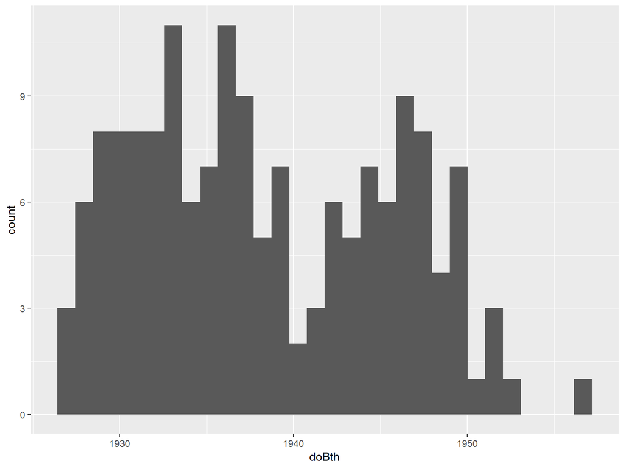

```r
plot_histo_spam <- function(df,histovar) {
out <- ggplot(df) +
  geom_histogram(mapping = aes( {{histovar}} ))

  return(out)
}

plot_histo_spam(steno2,doBth)
```

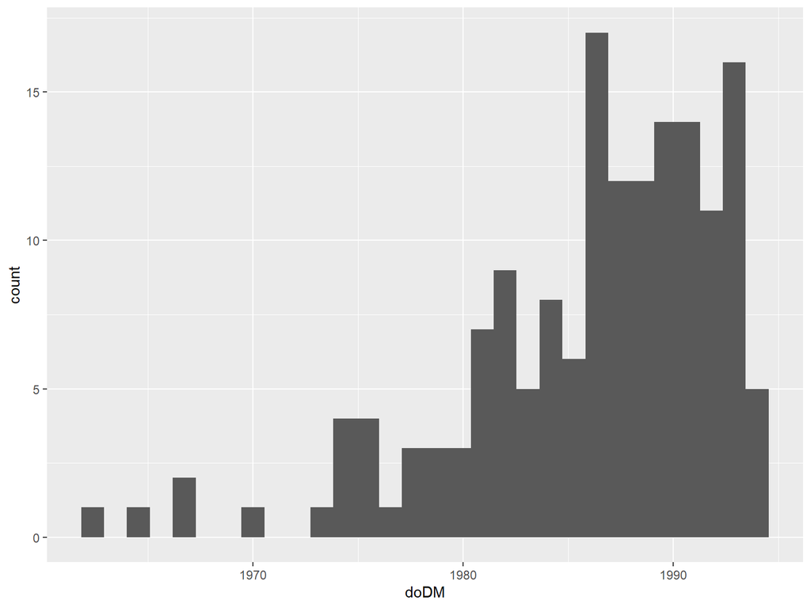

```r
plot_histo_spam(steno2,doDM)
```

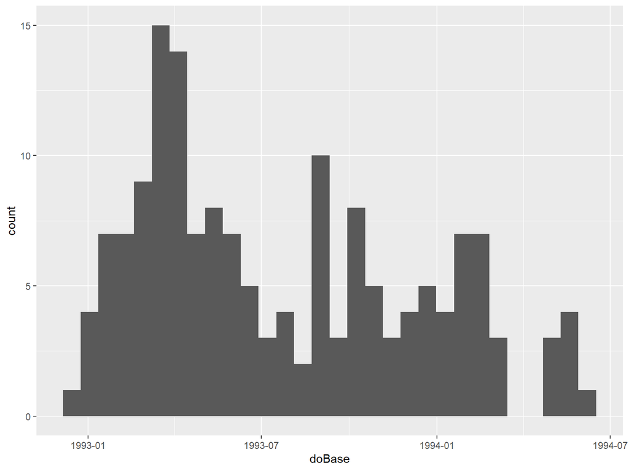

```r
plot_histo_spam(steno2,doBase)
```

But this should be doable in a smarter way. A `facet_wrap()` over each of the date variables..

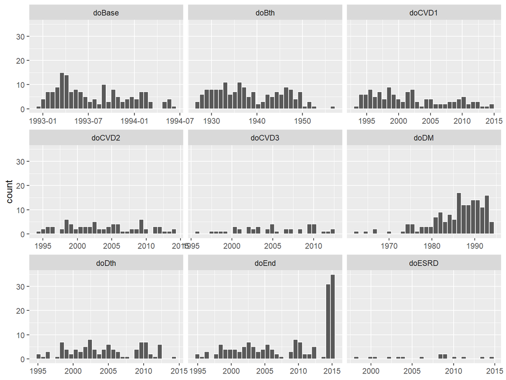

```r
plot_histospam_faceted <- function(data, prefix = "do") {
  data |>
    select(starts_with(prefix)) |>
    pivot_longer(everything()) |> # everything() turns varnames into a column, and their values into a separate column
    ggplot(aes(value)) +
      geom_histogram(colour = "white") +
      facet_wrap(~ name, scales = "free_x") +   # one panel per variable
      labs(x = NULL)
}

plot_histospam_faceted(steno2)
```

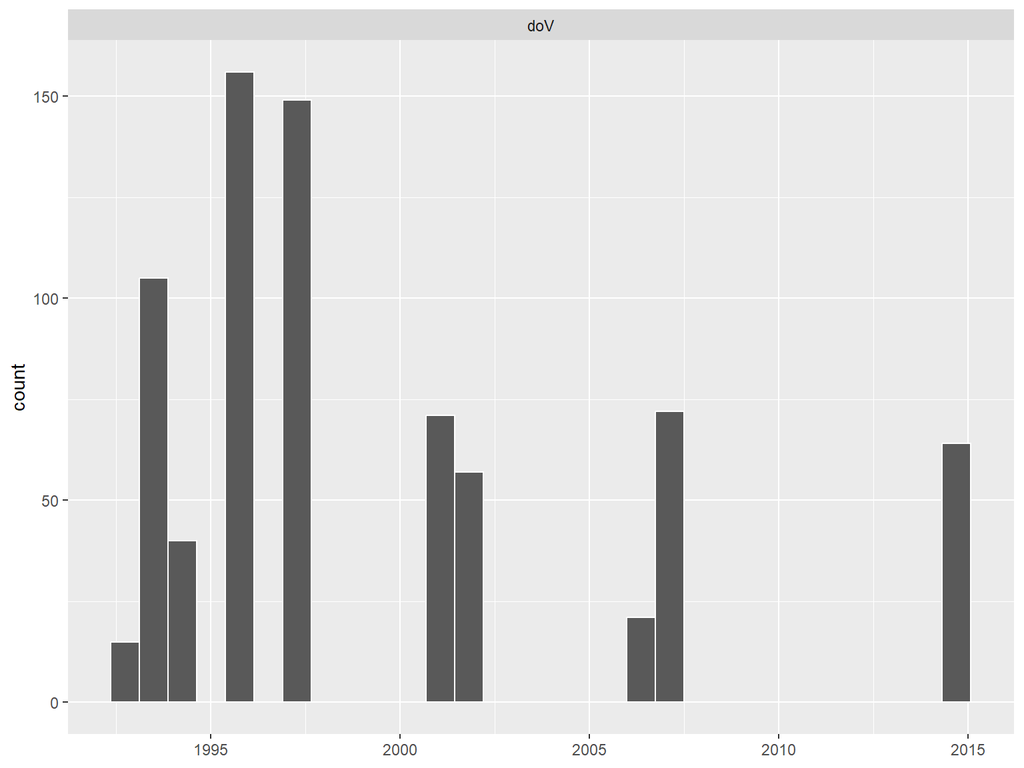

```r
plot_histospam_faceted(st2clin)
```

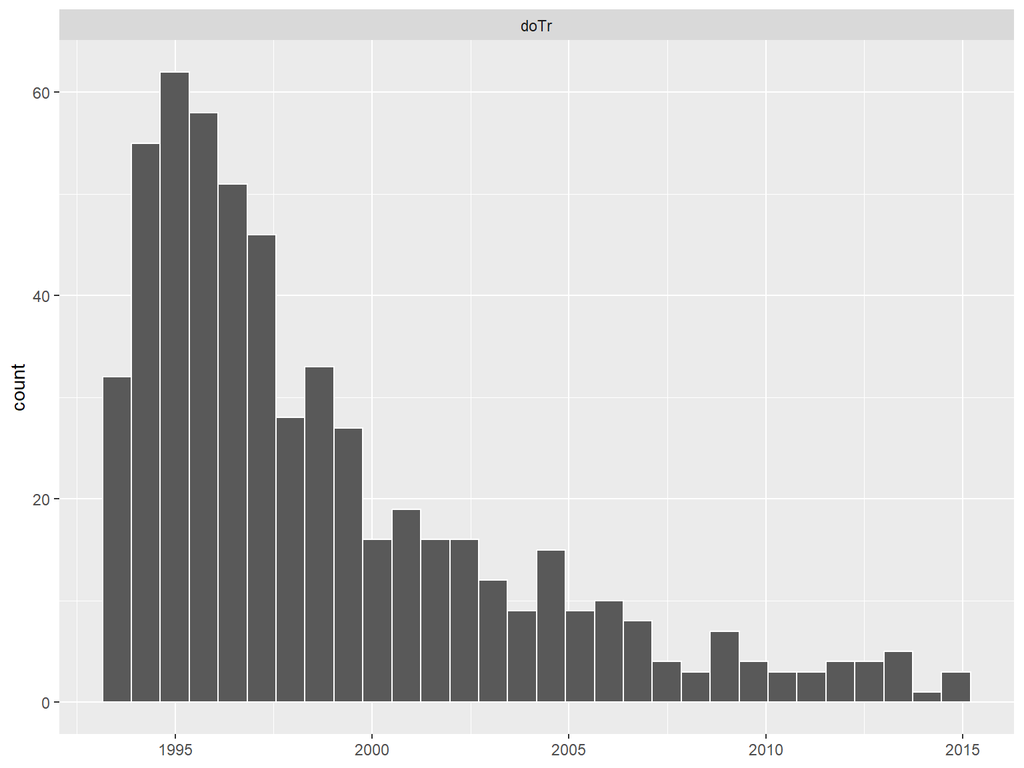

```r
plot_histospam_faceted(st2alb)
```

Now those are some fine basic plots!

For `steno2`, it shows some slight right skewed `doBase`, and left-skewed `doDM` and `doEnd`. for the two `st2*` data-sets, it shows quite a right skew.

**Basically**:

- most of the signups to the trial occurred in the beginning
- most of the CVD (cardiovascular) and death events occurred evenly-ish
- most of the diabetes diagnoses occurred late
- not much ESRD (end-stage renal disease) occurred

#### 3.2.2 Distributions by sex

Now I want to figure out how to do it while grouping the histograms by sex.

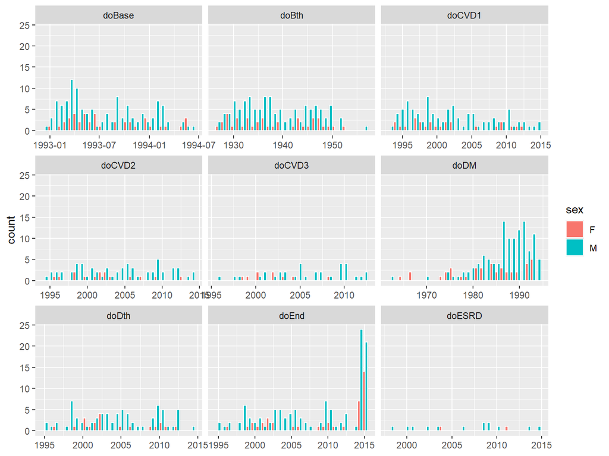

```r
plot_histospam_faceted_sex <- function(data, prefix = "do") {
  data |>
    select(sex, starts_with(prefix)) |>
    pivot_longer(-sex,
                 names_to = "name",
                 values_to = "value") |>
    ggplot(aes(value, fill = sex)) +
      geom_histogram(
        position = "dodge",
        colour = "white") +
      facet_wrap(~ name, scales = "free_x") +   # one panel per variable
      labs(x = NULL)
}

plot_histospam_faceted_sex(steno2)
```

Ok. Not much of a difference at a glance.

#### 3.2.3 Distributions by treatment groups

Perhaps it would be more relevant to see if there was some kind of difference between the two intervention groups?

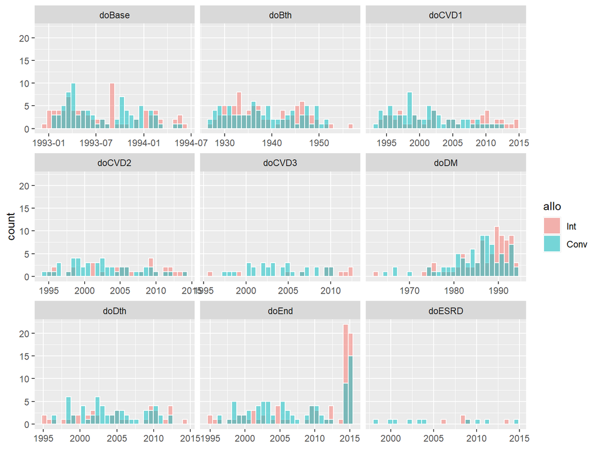

```r
plot_histospam_faceted_allo <- function(data, prefix = "do") {
  data |>
    select(allo, starts_with(prefix)) |>
    pivot_longer(-allo,
                 names_to = "name",
                 values_to = "value") |>
    ggplot(aes(value, fill = allo)) +
      geom_histogram(
        position = "identity",
        alpha    = 0.5,
        colour = "white") +
      facet_wrap(~ name, scales = "free_x") +   # one panel per variable
      labs(x = NULL)
}

plot_histospam_faceted_allo(steno2)
```

Ok so already here its possible to see some apparent differences between the two groups.

- the `Conv` allocation group, which must be those allocated to conventional treatment, whatever that was, have more events of CVD, especially of the third CVD event. As well as earlier diabetes mellitus (DM) diagnoses. This is probably an indication of the future results of the survival analysis.
- `Int` group, likely the intervention group, seems to have less deaths and later DM diagnoses

**Remember, these are two groups of equal number**, which can make it easier to conclude that there is a difference, at least initially and visually.

Now. With the help of some AI, I made the function below which can produce different types of `facet_*` plots , but I choose the `facet_grid`, because its interesting to look at.

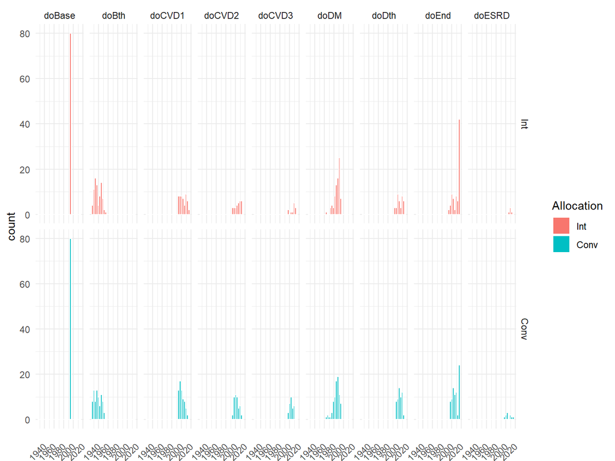

```r
steno2 |>
    select(allo, starts_with("do")) |>
    pivot_longer(-allo, names_to = "variable", values_to = "value") |>
    ggplot(aes(value, fill = allo)) +
    geom_histogram(position = "identity", colour = "white") +
        facet_grid(rows = vars(allo), cols = vars(variable)) +
    #scale_x_continuous(breaks = floor(min(value)):ceiling(max(value)),
    #               labels  = scales::number_format(accuracy = 1)) +
    labs(x = NULL, fill = "Allocation") +
    theme_minimal() +
    theme(axis.text.x = element_text(angle = 45, vjust = .5, hjust = 1))
```

This might be information overload to such a degree that not much is gained from it.

### 3.3 C) Model

To perform a basic Cox Proportional Hazards model, we can use the `survival` package.

I want to do the following, just because that’s what I learned in the olden PhD studying days, mainly from the Basic Biostats courses from Aarhus University:

- Survival set the data
- Visualise follow-up
- Plot Kaplan Meier survival function
- Cox model
  - Estimate
  - Observed vs fitted survival curves
  - Testing proportional hazards assumption

Let’s just quickly and without much thinking (thats always good), decide what the start, stop, outcome, and other variables should be.

- data: `steno2`
  - comparison: death `doDth` for intervention groups `allo`
  - start date: `doBase`
  - censor date: `doEnd`
  - outcome event: `doDth`
  - exit of study: earliest of `doEnd` and `doDth`

So, super basic, and does not take anything into account, such as competing events (`doCVD*` or `doESRD`) or baseline differences in risk of CVD (`baseCVD`).

#### 3.3.1 Survival set the data

First we create the needed variables and check it.

```r
steno2 <- steno2 |>
  mutate(
    doExit = coalesce(doDth, doEnd),
    time_days = difftime(
      coalesce(steno2$doDth, steno2$doEnd),
      steno2$doBase,
      units='days'),
    time_yrs = as.numeric(time_days / 365.25),
    event_num = if_else(!is.na(doDth),1,0),
    event = factor(event_num, levels = c(0, 1), labels = c("Censored", "Dead"))
  )

glimpse(steno2)
```

```
Rows: 160
Columns: 19
$ id        <dbl> 1, 2, 3, 4, 5, 6, 7, 8, 9, 10, 11, 12, 13, 14, 15, 16, 17, 1…
$ allo      <fct> Int, Int, Conv, Conv, Conv, Conv, Conv, Int, Int, Int, Int, …
$ sex       <fct> M, M, M, M, M, M, F, M, M, M, M, M, M, M, F, M, F, F, M, M, …
$ baseCVD   <dbl> 0, 0, 0, 0, 0, 1, 0, 0, 0, 0, 0, 1, 0, 0, 0, 1, 0, 0, 0, 0, …
$ deathCVD  <dbl> 0, 0, 0, 0, 1, 0, 0, 0, 1, 0, 1, 1, 0, 0, 0, 0, 0, 0, 0, 0, …
$ doBth     <date> 1932-04-11, 1946-11-09, 1943-06-07, 1944-11-01, 1935-12-22,…
$ doDM      <date> 1991-01-21, 1982-01-30, 1982-07-17, 1976-10-28, 1986-05-06,…
$ doBase    <date> 1993-04-30, 1993-06-08, 1993-05-17, 1993-05-04, 1993-03-23,…
$ doCVD1    <date> 2014-05-24, 2009-03-15, 2001-08-28, 1995-05-31, 1993-12-16,…
$ doCVD2    <date> NA, 2009-07-02, NA, 1997-06-26, 1994-08-05, NA, 2006-02-27,…
$ doCVD3    <date> NA, 2010-02-16, NA, 2003-06-17, 1997-12-25, NA, NA, NA, NA,…
$ doESRD    <date> NaN, NaN, NaN, NaN, 1998-02-18, 2014-07-07, NaN, 2009-03-06…
$ doEnd     <date> 2014-10-12, 2014-08-04, 2001-08-21, 2003-06-11, 1998-01-18,…
$ doDth     <date> NA, NA, 2001-09-20, 2003-06-24, 1998-02-25, NA, 2006-04-24,…
$ doExit    <date> 2014-10-12, 2014-08-04, 2001-09-20, 2003-06-24, 1998-02-25,…
$ time_days <drtn> 7834.3828 days, 7726.4177 days, 3048.4091 days, 3703.4893 d…
$ time_yrs  <dbl> 21.449371, 21.153779, 8.346089, 10.139601, 4.929256, 21.4398…
$ event_num <dbl> 0, 0, 1, 1, 1, 0, 1, 1, 1, 1, 1, 1, 0, 1, 0, 1, 0, 0, 0, 0, …
$ event     <fct> Censored, Censored, Dead, Dead, Dead, Censored, Dead, Dead, …
```

#### 3.3.2 Visualise follow-up

Then, because I like it as an overview, a swimmer plot of the follow-up times.

simple first:

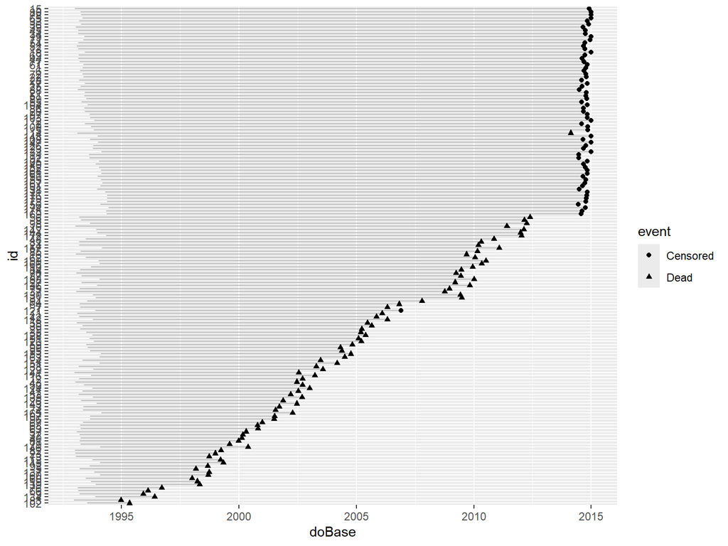

```r
swim_plot_1 <- steno2 |>
  mutate(id = fct_reorder(as.factor(id), time_yrs)) |>
  ggplot(aes(x = doBase,
             xend = doExit,
             y = id)) +
  geom_segment(color = "grey") +
  geom_point(aes(x = doExit, shape = event)) +
  geom_point(aes(x = doDth, shape = event))
swim_plot_1
```

Looks good, but a tiny bit messy with the - although accurate - different starting times.

Lets do one with baseline time set to 0. This makes it easier to compare the follow-up times, which is more interesting for the analysis than calendar times.

The latter would probably be of more interest to an investigator trying to figure out when people signed up, or something.

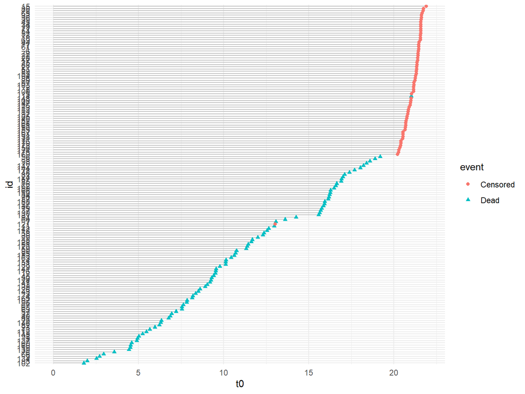

```r
swim_plot_2 <- steno2 |>
  mutate(
    id = fct_reorder(as.factor(id), time_yrs),
    t0 = 0) |>
  ggplot(aes(x = t0,
             xend = time_yrs,
             y = id)) +
  geom_segment(color = "grey") +
  geom_point(aes(x = time_yrs, shape = event, colour = event)) +
  theme_minimal()
swim_plot_2
```

Here we have the x-axis in years since baseline.

Now, I have a sense that `doExit` and `doDth` are the same, meaning that plots that use `doExit` end up having two shapes for subjects that died.

How can I make it so that there are different shapes for each event? I can just take the previous plot and add to it.

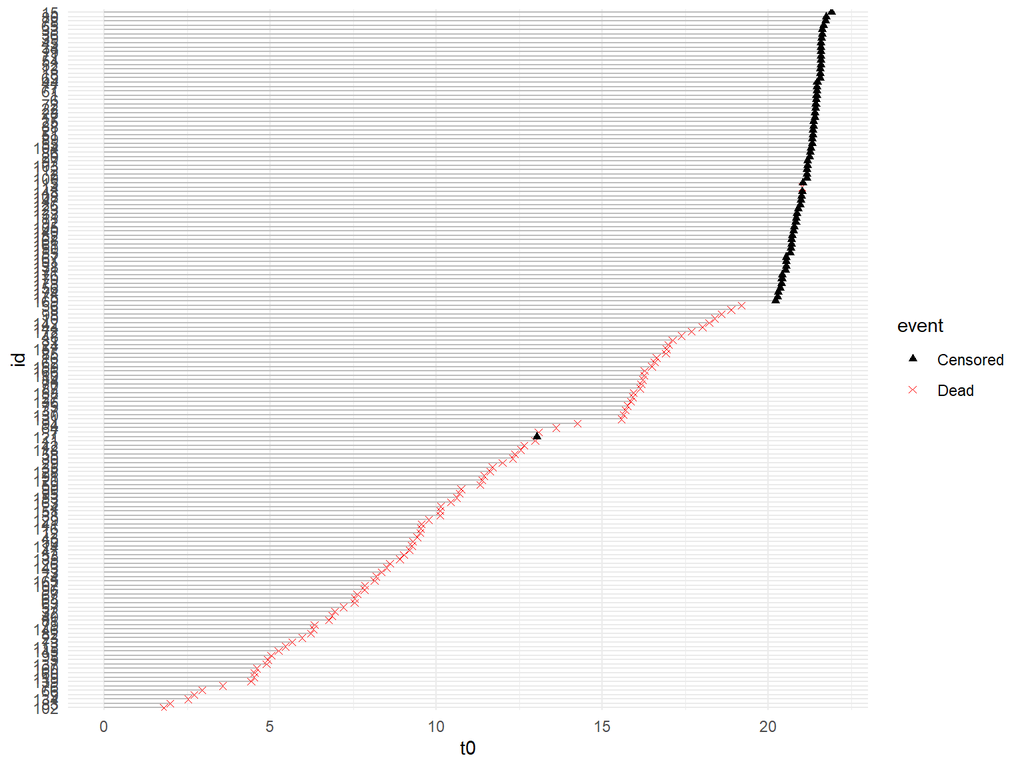

```r
swim_plot_3 <- swim_plot_2 +
  scale_shape_manual(values = c(Censored = 17, Dead = 4)) +
  scale_colour_manual(values = c(Censored = "black", Dead = "red"))
swim_plot_3
```

Ok that looks fine. Now I want to make the final plot for this and move on.

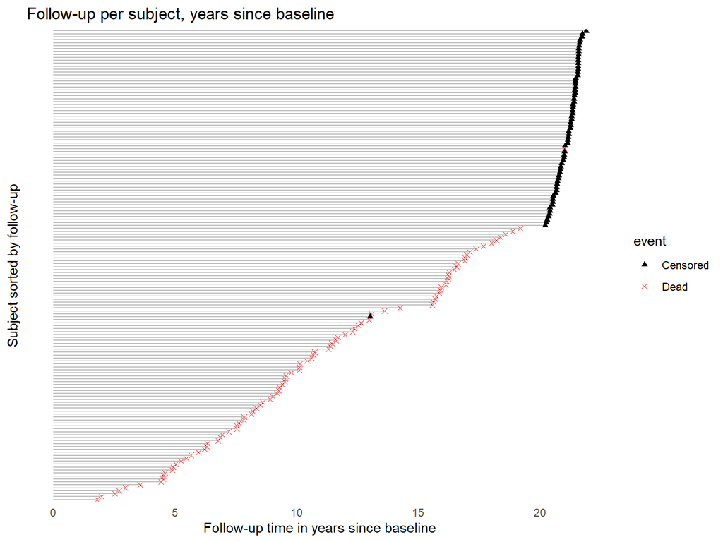

```r
swim_plot_4 <- swim_plot_3 +
  labs(
    x = "Follow-up time in years since baseline",
    y = "Subject sorted by follow-up",
    title = "Follow-up per subject, years since baseline") +
  theme(
    axis.text.y = element_blank(),
    axis.ticks.y = element_blank(),
    panel.grid.minor = element_blank(),
    panel.grid.major = element_blank()
    )
swim_plot_4
```

```r
ggsave("thumbnail.jpg", plot = last_plot(), width = 6, height = 4) # saved as thumbnail
```

A nice little plot showing an overview of the length of follow-up for the subjects in the study.

Not exactly sure how it is useful except for my own sake - I just like to know *visually* what my data looks like.

#### 3.3.3 Disclaimer

I am not a statistician, so whatever is correct of below, is due to the wise words and lectures I have remembered from people who actually know what they are talking about. Many statistical results, especially when you wish to talk inference (X causes Y), require careful consideration of subjective priors, demographics, causal effects, and biases such as effect modifiers, confounders, selection bias, etc.

Now - with that out of the way: LETS CLAIM SOME THINGS!

#### 3.3.4 Plot Kaplan Meier survival function

Now, less fiddling around with plots, and more looking at survival analysis.

The Kaplan meier estimator on a plot is wonderful for portraying differences in survival times. First step we have is to fit the data.

```r
# Overall, by treatment allocation, subset into sex
km_os <- survfit(Surv(time_yrs, event_num) ~ 1, data = steno2)
km_allo <- survfit(Surv(time_yrs, event_num) ~ allo, data = steno2)
km_sex <- survfit(Surv(time_yrs, event_num) ~ sex, data = steno2)
km_allo_sex <- survfit(Surv(time_yrs, event_num) ~ allo + sex, data = steno2)

# Summarising, showing just the first 10 years
summary(km_os, times=c(0:10))
```

```
Call: survfit(formula = Surv(time_yrs, event_num) ~ 1, data = steno2)

 time n.risk n.event survival std.err lower 95% CI upper 95% CI
    0    160       0    1.000 0.00000        1.000        1.000
    1    160       0    1.000 0.00000        1.000        1.000
    2    158       2    0.988 0.00878        0.970        1.000
    3    155       3    0.969 0.01376        0.942        0.996
    4    154       1    0.963 0.01502        0.934        0.992
    5    148       6    0.925 0.02082        0.885        0.967
    6    143       5    0.894 0.02436        0.847        0.943
    7    137       6    0.856 0.02774        0.804        0.912
    8    131       6    0.819 0.03045        0.761        0.881
    9    125       6    0.781 0.03268        0.720        0.848
   10    116       9    0.725 0.03530        0.659        0.798
```

```r
summary(km_allo, times=c(0:10))
```

```
Call: survfit(formula = Surv(time_yrs, event_num) ~ allo, data = steno2)

                allo=Int
 time n.risk n.event survival std.err lower 95% CI upper 95% CI
    0     80       0    1.000  0.0000        1.000        1.000
    1     80       0    1.000  0.0000        1.000        1.000
    2     78       2    0.975  0.0175        0.941        1.000
    3     77       1    0.963  0.0212        0.922        1.000
    4     76       1    0.950  0.0244        0.903        0.999
    5     75       1    0.938  0.0271        0.886        0.992
    6     73       2    0.913  0.0316        0.853        0.977
    7     70       3    0.875  0.0370        0.805        0.951
    8     66       4    0.825  0.0425        0.746        0.913
    9     64       2    0.800  0.0447        0.717        0.893
   10     63       1    0.788  0.0457        0.703        0.882

                allo=Conv
 time n.risk n.event survival std.err lower 95% CI upper 95% CI
    0     80       0    1.000  0.0000        1.000        1.000
    1     80       0    1.000  0.0000        1.000        1.000
    2     80       0    1.000  0.0000        1.000        1.000
    3     78       2    0.975  0.0175        0.941        1.000
    4     78       0    0.975  0.0175        0.941        1.000
    5     73       5    0.913  0.0316        0.853        0.977
    6     70       3    0.875  0.0370        0.805        0.951
    7     67       3    0.838  0.0412        0.760        0.922
    8     65       2    0.813  0.0436        0.731        0.903
    9     61       4    0.763  0.0476        0.675        0.862
   10     53       8    0.663  0.0529        0.567        0.775
```

```r
summary(km_sex, times=c(0:10))
```

```
Call: survfit(formula = Surv(time_yrs, event_num) ~ sex, data = steno2)

                sex=F
 time n.risk n.event survival std.err lower 95% CI upper 95% CI
    0     41       0    1.000  0.0000        1.000        1.000
    1     41       0    1.000  0.0000        1.000        1.000
    2     41       0    1.000  0.0000        1.000        1.000
    3     40       1    0.976  0.0241        0.930        1.000
    4     40       0    0.976  0.0241        0.930        1.000
    5     40       0    0.976  0.0241        0.930        1.000
    6     39       1    0.951  0.0336        0.888        1.000
    7     37       2    0.902  0.0463        0.816        0.998
    8     34       3    0.829  0.0588        0.722        0.953
    9     31       3    0.756  0.0671        0.635        0.900
   10     29       2    0.707  0.0711        0.581        0.861

                sex=M
 time n.risk n.event survival std.err lower 95% CI upper 95% CI
    0    119       0    1.000  0.0000        1.000        1.000
    1    119       0    1.000  0.0000        1.000        1.000
    2    117       2    0.983  0.0118        0.960        1.000
    3    115       2    0.966  0.0165        0.935        0.999
    4    114       1    0.958  0.0184        0.923        0.995
    5    108       6    0.908  0.0266        0.857        0.961
    6    104       4    0.874  0.0304        0.816        0.936
    7    100       4    0.840  0.0336        0.777        0.909
    8     97       3    0.815  0.0356        0.748        0.888
    9     94       3    0.790  0.0373        0.720        0.867
   10     87       7    0.731  0.0406        0.656        0.815
```

```r
summary(km_allo_sex, times=c(0:10))
```

```
Call: survfit(formula = Surv(time_yrs, event_num) ~ allo + sex, data = steno2)

                allo=Int, sex=F
 time n.risk n.event survival std.err lower 95% CI upper 95% CI
    0     17       0    1.000  0.0000        1.000            1
    1     17       0    1.000  0.0000        1.000            1
    2     17       0    1.000  0.0000        1.000            1
    3     17       0    1.000  0.0000        1.000            1
    4     17       0    1.000  0.0000        1.000            1
    5     17       0    1.000  0.0000        1.000            1
    6     17       0    1.000  0.0000        1.000            1
    7     17       0    1.000  0.0000        1.000            1
    8     15       2    0.882  0.0781        0.742            1
    9     14       1    0.824  0.0925        0.661            1
   10     14       0    0.824  0.0925        0.661            1
```

[output cut: 42 more lines]

Here we can see that after 10 years, there is already a lower survival probability for the conventional treatment group. And for females, it seems. But that highly depends on the intervention group.

But it is much better to visualize it with a kaplan meier plot, to really see the differences, and when - in terms of time since baseline - does the survival differ.

Shown below are plots for each of the different fits mentioned above, showing the overall survival modelel, differences in survival between intervention groups for both sexes, and ditto, but subset for each sex.

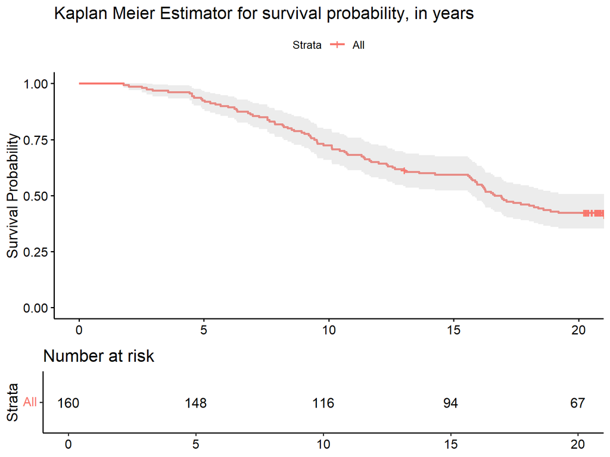

```r
# Function to save some space
survplot_function <- function(fit,data){
  out <- ggsurvplot(
    fit, data = data,
    conf.int = TRUE,
    risk.table = TRUE,
    palette = "dark2",
    xlab = NULL, ylab = "Survival Probability",
    title = "Kaplan Meier Estimator for survival probability, in years"
    )

  return(out)
}

# Overall
survplot_function(km_os,steno2)
```

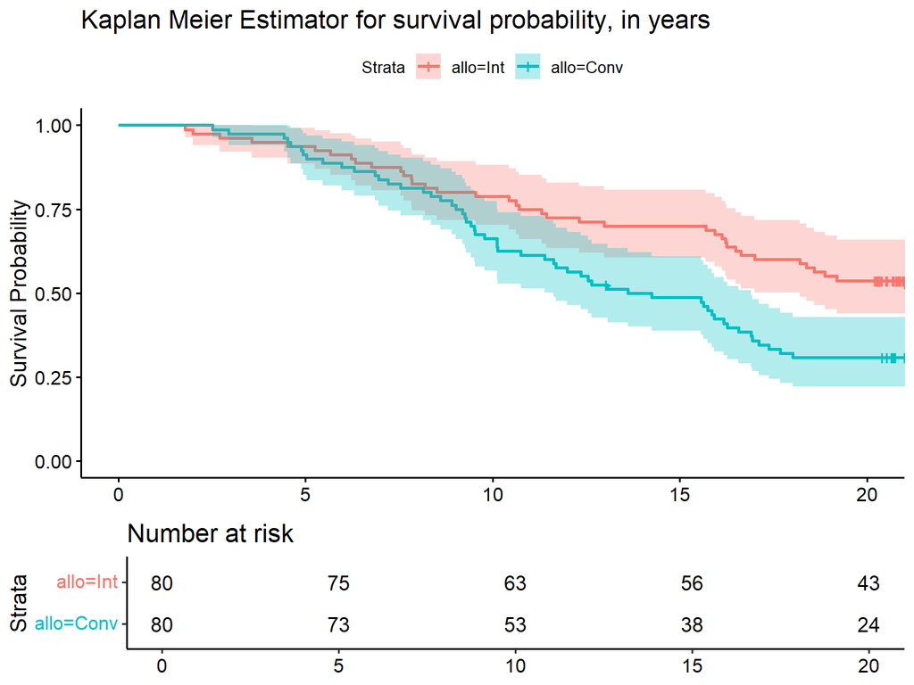

```r
# allo
survplot_function(km_allo,steno2)
```

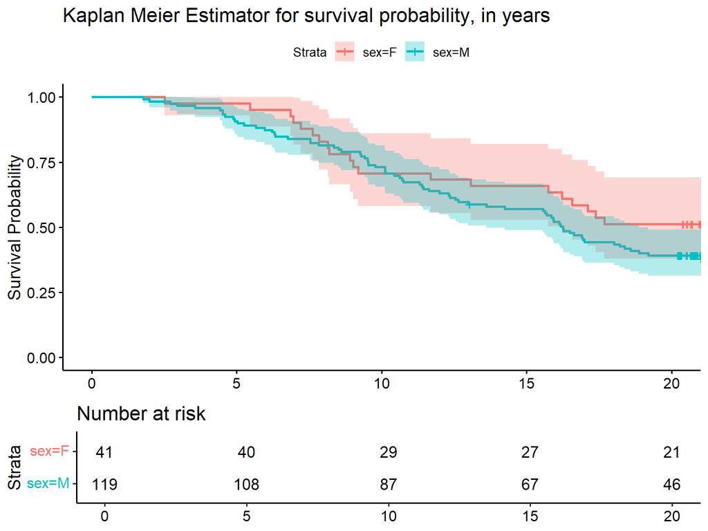

```r
# sex
survplot_function(km_sex,steno2)
```

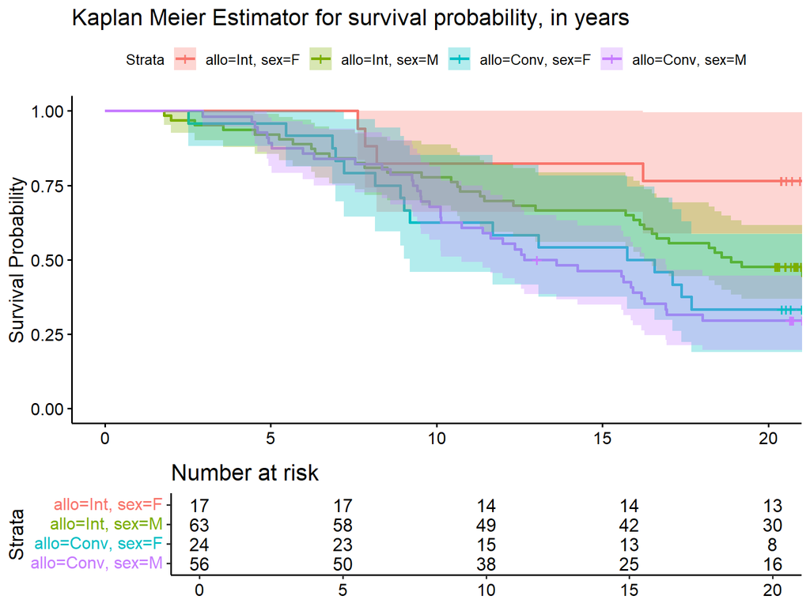

```r
# allo sex
survplot_function(km_allo_sex,steno2)
```

Thats a bit rough to look at, but provides plenty of information:

1. intervention group has higher survival probability
2. female sex seems to indicate having the highest survival probability, at least in intervention group
3. frequently overlapping confidence intervals, low probability of actual difference atleast in the first 10 years where most of the overlap occurs

For the second point, the lines cross twice, either because of the lower number of females or because of some unknown factor. When the lines cross its difficult to say whether there is any consistent survival difference with certainty.

But let’s try to make it pretty - just with the help of the `survminer` package help - accessed in Rstudio via `?ggsurvplot`.

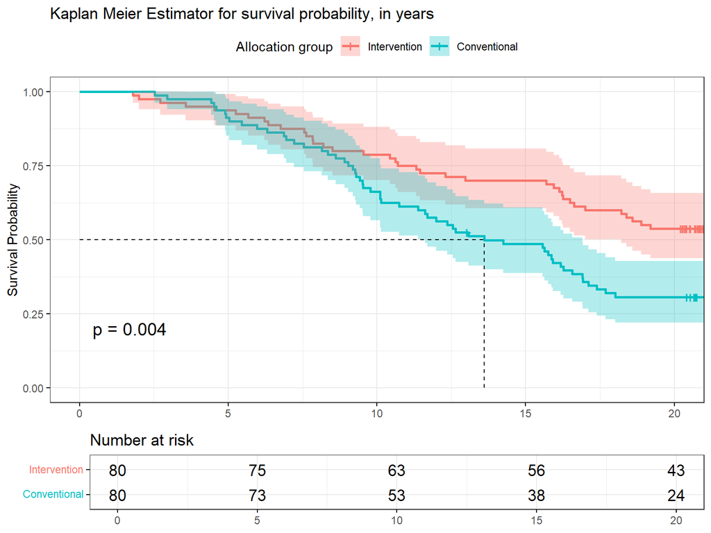

```r
# allo
surv_p_allo_pretty <- ggsurvplot(
  fit = km_allo, data = steno2,
  surv.median.line = "hv", # Add medians survival
  legend.title = "Allocation group",
  legend.labs = c("Intervention", "Conventional"),
  pval = TRUE,
  conf.int = TRUE,

  risk.table = TRUE,
  tables.height = 0.2,
  tables.theme = theme(axis.title.y = element_blank()),

  palette = "dark2",
  ggtheme = theme_bw(),
  xlab = NULL, ylab = "Survival Probability",
  title = "Kaplan Meier Estimator for survival probability, in years"
  )

surv_p_allo_sex_pretty <- ggsurvplot(
  fit = km_allo_sex, data = steno2,
  surv.median.line = "hv", # Add medians survival
  legend.title = "Allocation group, Sex",
  legend.labs = c("Int, F", "Int, M", "Conv, F", "Conv, M"),
  conf.int = TRUE,

  risk.table = TRUE,
  tables.height = 0.2,
  tables.theme = theme(axis.title.y = element_blank()),

  palette = "dark2",
  ggtheme = theme_bw(),
  xlab = NULL, ylab = "Survival Probability",
  title = "Kaplan Meier Estimator for survival probability, in years"
  )
surv_p_allo_pretty
```

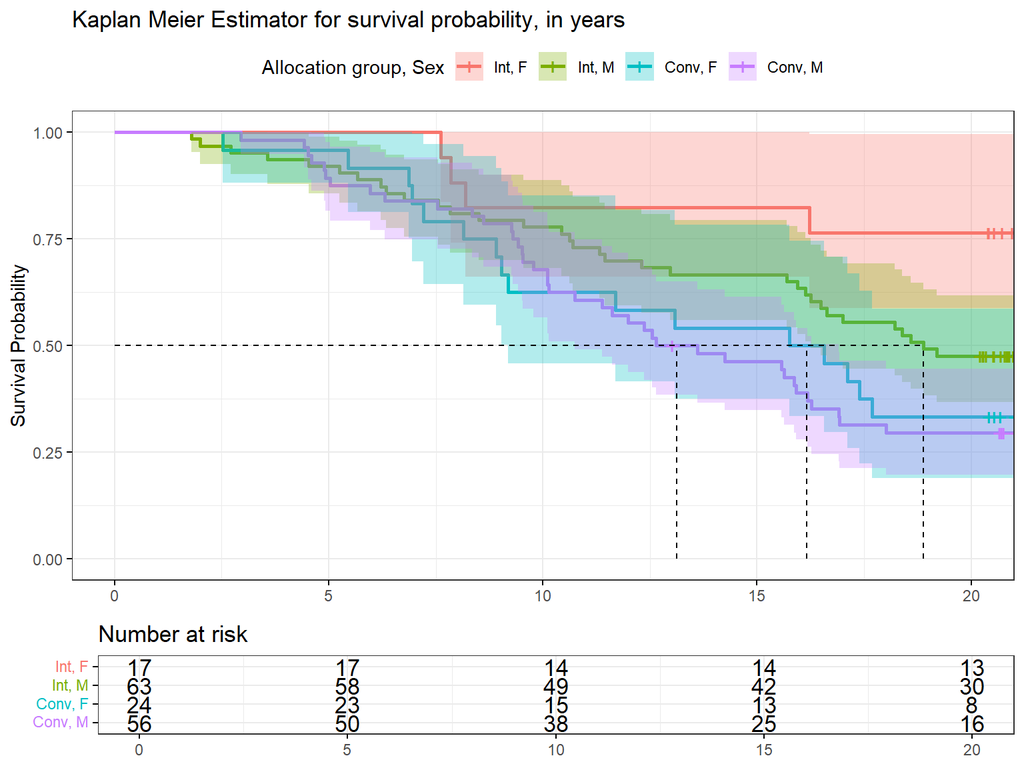

```r
surv_p_allo_sex_pretty
```

Now slightly cleaned up, and with some median survival lines - the follow-up time at which 50 has experienced the event - added.

##### 3.3.4.1 Test of differences

One way of testing the differences between two survival curves is the log-rank test. Although, as far as I remember, its not given much weight - especially compared to visual inspection coupled with careful thinking and analysis of the different factors that play into a survival analysis.

```r
survdiff(Surv(time_yrs, event_num) ~ allo, data = steno2)
```

```
Call:
survdiff(formula = Surv(time_yrs, event_num) ~ allo, data = steno2)

           N Observed Expected (O-E)^2/E (O-E)^2/V
allo=Int  80       38     51.7      3.64      8.29
allo=Conv 80       55     41.3      4.56      8.29

 Chisq= 8.3  on 1 degrees of freedom, p= 0.004
```

```r
survdiff(Surv(time_yrs, event_num) ~ sex, data = steno2)
```

```
Call:
survdiff(formula = Surv(time_yrs, event_num) ~ sex, data = steno2)

        N Observed Expected (O-E)^2/E (O-E)^2/V
sex=F  41       20     25.5     1.182      1.63
sex=M 119       73     67.5     0.446      1.63

 Chisq= 1.6  on 1 degrees of freedom, p= 0.2
```

Seems there is a statistically significant difference between allocation groups and not sex. Kinda what I expected from the reading of the plots.

I have forgotten how to interpret the log-rank model for a fit with two different binary variables, so I will refrain from attempting that at the moment.

#### 3.3.5 Cox model

Now we enter the part of survival analysis where we want to see what effect sizes the different predictors have on the outcome.

As mentioned in Section 3.3.3, I am not a statistician, and I do not think the target audience of 0 to 1/3 of a person should be a statistician, so I will not bombard You with all the equations and definitions of survival analysis, such as $S(t) = P(T>t) = etc..etc$.

I will just try to write in plain terms.

Where the survival function derived from the Kaplan Meier Estimator up above could tell us how many people have survived at time $t$, and the difference between groups, the cox proportional hazards model can describe the relative difference in effect between different predictors, in regards to the risk of the outcome.

Spoken plainly: the cox proportional hazards model can tell us something about how much the risk of the outcome, `doDth`, increases or decreases, for those in one group compared to another group. And then if there are multiple variables in the analysis, its assumed all other variables stay the same.

Let’s do the same models as for the survival function.

```r
# Overall, by treatment allocation, subset into sex
cox_allo <- coxph(Surv(time_yrs, event_num) ~ allo, data = steno2)
cox_sex <- coxph(Surv(time_yrs, event_num) ~ sex, data = steno2)
cox_allo_sex <- coxph(Surv(time_yrs, event_num) ~ allo + sex, data = steno2)
```

##### 3.3.5.1 Checking models out before interpreting estimates

Before we go ahead and interpret estimates, it is recommended that you see how the data fits with the assumptions that are necessary for the cox model to be interpreted correctly.

In general, I have been taught to test the cox proportional hazards assumption, which can be done in two ways:

- plot observed survival curves in the two groups with estimated survival curves from the model
- log log plot of two survival curves

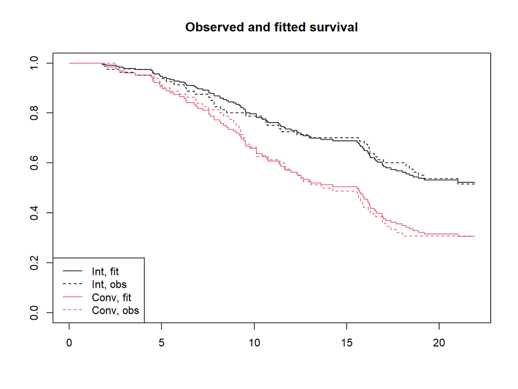

```r
plot(km_allo,
     col=1:2,
     lty=2,
     main='Observed and fitted survival')
lines(survfit(cox_allo,
              newdata=data.frame(allo=c('Int','Conv'))),
      col=1:2)
legend('bottomleft',
       lty=rep(1:2,2),col=rep(1:2,each=2),
       legend=c('Int, fit','Int, obs','Conv, fit','Conv, obs'))
```

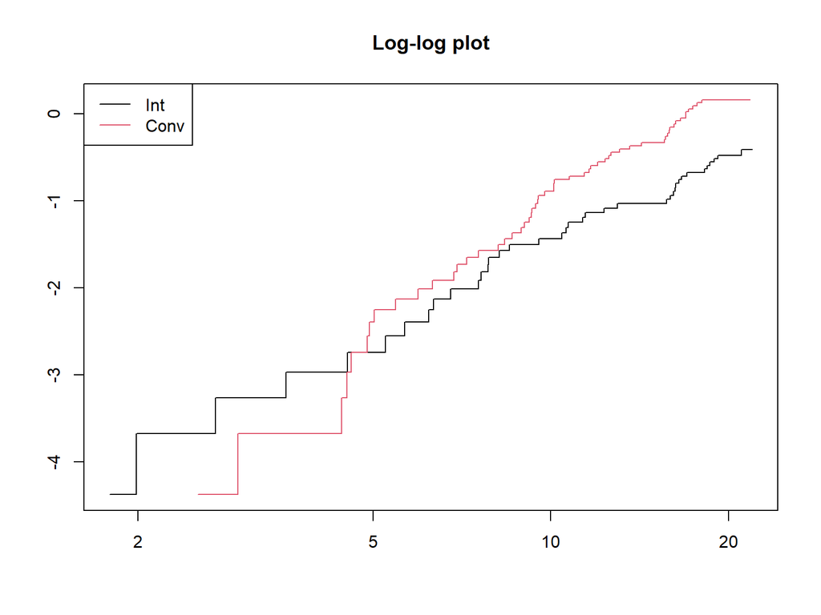

```r
plot(km_allo,
     col=1:2,
     fun='cloglog',
     main='Log-log plot')
legend('topleft',lty=rep(1,2),col=1:2,legend=levels(steno2$allo))
```

Hmm. I also wanted to use `ggsurvplot` but for some reason, I can only get the old code, without risk table, from my course long ago in basic biostats to work, so I will use that.

**But more importantly:**

Basically what we can see from the two above plots is that the proportional hazards assumption doesn’t hold well, due to crossover of survival curves and perhaps a slight possibility of different baseline hazards.

If the hazards for the groups being compared are not relatively proportional over time, its estimates do not precisely answer the question of “how much more risk is one group in of the outcome versus the other”, since it varies over time.

It answers a general tendency, which might switch at some point in the data, as can be seen by earlier plots where observed survival curves overlap early.

##### 3.3.5.2 Estimates

But lets still look at the model estimates and interpret them a bit, but bearing in mind that the proportional hazards assumption doesn’t hold.

For a more simple output of the models, I use `broom::tidy()`.

```r
# list
cox_models <- list(cox_allo,cox_sex,cox_allo_sex)
names(cox_models) <- paste0("model_", seq_along(cox_models))

# tidy
tidy_cox_models <- map_dfr(cox_models, ~broom::tidy(.x, conf.int = TRUE))
tidy_cox_models
```

```
# A tibble: 4 × 7
  term     estimate std.error statistic p.value conf.low conf.high
  <chr>       <dbl>     <dbl>     <dbl>   <dbl>    <dbl>     <dbl>
1 alloConv    0.602     0.212      2.84 0.00455    0.186     1.02
2 sexM        0.321     0.253      1.27 0.203     -0.174     0.816
3 alloConv    0.628     0.213      2.95 0.00316    0.211     1.05
4 sexM        0.379     0.253      1.50 0.135     -0.118     0.875
```

```r
tidy_cox_models_exp <- map_dfr(cox_models, ~broom::tidy(.x, conf.int = TRUE, exponentiate = TRUE))
tidy_cox_models_exp
```

```
# A tibble: 4 × 7
  term     estimate std.error statistic p.value conf.low conf.high
  <chr>       <dbl>     <dbl>     <dbl>   <dbl>    <dbl>     <dbl>
1 alloConv     1.83     0.212      2.84 0.00455    1.20       2.77
2 sexM         1.38     0.253      1.27 0.203      0.840      2.26
3 alloConv     1.87     0.213      2.95 0.00316    1.23       2.84
4 sexM         1.46     0.253      1.50 0.135      0.889      2.40
```

Where the first two rows are the first two models, and row three to four is the model with both variables, so you can see how much of an effect it has if you include them both.

Let’s go ahead and do a simple interpretation on the model with both allocation and sex as predictors.

Using `broom::augment`, one can plop the estimates into a table as an overview of what the model estimates mean for each variable.

```r
cox_grid_1 <- expand.grid(allo = c("Conv", "Int"))
cox_grid_2 <- expand.grid(allo = c("Conv", "Int"), sex = c("M","F"))
(broom::augment(cox_allo,newdata = cox_grid_1, type.predict = "risk"))
```

```
# A tibble: 2 × 3
  allo  .fitted .se.fit
  <fct>   <dbl>   <dbl>
1 Conv     1.83   0.287
2 Int      1      0
```

```r
(broom::augment(cox_allo_sex,newdata = cox_grid_2, type.predict = "risk"))
```

```
# A tibble: 4 × 4
  allo  sex   .fitted .se.fit
  <fct> <fct>   <dbl>   <dbl>
1 Conv  M        2.74   0.567
2 Int   M        1.46   0.306
3 Conv  F        1.87   0.291
4 Int   F        1      0
```

Due to the `type.predict` option, the result is exponentiated so it can be interpreted as risk increase.

So, the model output for `cox_allo_sex` can be interpreted in the following way:

Females on intervention treatment are the reference group, and females with conventional treatment have 87% higher risk of death, while males on intervention treatment have 46%, and males on conventional 174% higher risk.

## 4 Summary / cleaned up / refactored

```
Rows: 160
Columns: 14
$ id       <dbl> 1, 2, 3, 4, 5, 6, 7, 8, 9, 10, 11, 12, 13, 14, 15, 16, 17, 18…
$ allo     <fct> Int, Int, Conv, Conv, Conv, Conv, Conv, Int, Int, Int, Int, C…
$ sex      <fct> M, M, M, M, M, M, F, M, M, M, M, M, M, M, F, M, F, F, M, M, F…
$ baseCVD  <dbl> 0, 0, 0, 0, 0, 1, 0, 0, 0, 0, 0, 1, 0, 0, 0, 1, 0, 0, 0, 0, 0…
$ deathCVD <dbl> 0, 0, 0, 0, 1, 0, 0, 0, 1, 0, 1, 1, 0, 0, 0, 0, 0, 0, 0, 0, 0…
$ doBth    <date> 1932-04-11, 1946-11-09, 1943-06-07, 1944-11-01, 1935-12-22, …
$ doDM     <date> 1991-01-21, 1982-01-30, 1982-07-17, 1976-10-28, 1986-05-06, …
$ doBase   <date> 1993-04-30, 1993-06-08, 1993-05-17, 1993-05-04, 1993-03-23, …
$ doCVD1   <date> 2014-05-24, 2009-03-15, 2001-08-28, 1995-05-31, 1993-12-16, …
$ doCVD2   <date> NA, 2009-07-02, NA, 1997-06-26, 1994-08-05, NA, 2006-02-27, …
$ doCVD3   <date> NA, 2010-02-16, NA, 2003-06-17, 1997-12-25, NA, NA, NA, NA, …
$ doESRD   <date> NaN, NaN, NaN, NaN, 1998-02-18, 2014-07-07, NaN, 2009-03-06,…
$ doEnd    <date> 2014-10-12, 2014-08-04, 2001-08-21, 2003-06-11, 1998-01-18, …
$ doDth    <date> NA, NA, 2001-09-20, 2003-06-24, 1998-02-25, NA, 2006-04-24, …
Rows: 750
Columns: 5
$ id   <dbl> 1, 2, 3, 4, 5, 6, 7, 8, 9, 10, 11, 12, 13, 14, 15, 16, 17, 18, 19…
$ doV  <date> 1993-05-07, 1993-05-05, 1993-05-11, 1993-05-12, 1993-02-25, 1993…
$ a1c  <dbl> 87.3, 66.5, 73.0, 61.2, 102.7, 93.4, 94.5, 103.9, 46.4, 84.4, 47.…
$ chol <dbl> 3.9, 6.6, 5.6, 5.2, 6.0, 4.8, 8.6, 5.1, 4.2, 5.4, 8.9, 5.3, 6.0, …
$ crea <dbl> 83, 83, 68, 97, 149, 55, 56, 78, 123, 79, 74, 84, 65, 52, 61, 61,…
Rows: 563
Columns: 3
$ id    <dbl> 1, 1, 1, 1, 1, 2, 2, 2, 2, 2, 3, 3, 3, 4, 4, 4, 5, 5, 6, 6, 6, 6…
$ doTr  <date> 1993-06-12, 1995-05-13, 2000-01-26, 2001-12-26, 2007-04-27, 199…
$ state <fct> Mic, Norm, Mic, Norm, Mic, Norm, Mic, Mac, Mic, Mic, Mic, Mic, M…
```

[output not shown]

[output cut: 1627 more lines]

```
[[1]]
  records max_id
1     160    176

[[2]]
  records max_id
1     160    176

[[3]]
  records max_id
1     156    176
```

```
[[1]]
   id allo sex baseCVD deathCVD      doBth       doDM     doBase     doCVD1
1  83  Int   M       0        1 1930-12-23 1989-06-28 1992-12-22 1994-12-04
2 102  Int   M       0        1 1935-04-09 1990-03-19 1993-07-17 1995-04-23
3 128 Conv   M       0        0 1937-03-14 1989-02-16 1993-10-03 1995-11-13
4 150 Conv   F       0        0 1946-02-18 1989-10-29 1993-12-24       <NA>
      doCVD2     doCVD3     doESRD      doEnd      doDth
1 1994-12-12       <NA>        NaN 1994-11-15 1994-12-19
2       <NA>       <NA>        NaN 1995-03-30 1995-05-02
3 2003-08-07 2004-05-31 1999-12-26 2005-05-19 2005-05-18
4       <NA>       <NA>        NaN 2014-08-27       <NA>

[[2]]
 [1] id       allo     sex      baseCVD  deathCVD doBth    doDM     doBase
 [9] doCVD1   doCVD2   doCVD3   doESRD   doEnd    doDth
<0 rows> (or 0-length row.names)
```

```
       id           allo    sex        baseCVD          deathCVD
 Min.   :  1.00   Int :80   F: 41   Min.   :0.0000   Min.   :0.0000
 1st Qu.: 40.75   Conv:80   M:119   1st Qu.:0.0000   1st Qu.:0.0000
 Median : 82.50                     Median :0.0000   Median :0.0000
 Mean   : 85.31                     Mean   :0.1375   Mean   :0.2375
 3rd Qu.:130.25                     3rd Qu.:0.0000   3rd Qu.:0.0000
 Max.   :176.00                     Max.   :1.0000   Max.   :1.0000

     doBth                 doDM                doBase
 Min.   :1926-07-13   Min.   :1962-06-21   Min.   :1992-12-22
 1st Qu.:1932-07-18   1st Qu.:1982-10-01   1st Qu.:1993-03-23
 Median :1937-03-12   Median :1987-05-02   Median :1993-06-11
 Mean   :1938-06-03   Mean   :1986-01-15   Mean   :1993-07-22
 3rd Qu.:1944-11-28   3rd Qu.:1990-05-03   3rd Qu.:1993-11-15
 Max.   :1956-04-07   Max.   :1994-02-07   Max.   :1994-06-14

     doCVD1               doCVD2               doCVD3
 Min.   :1993-03-17   Min.   :1994-08-05   Min.   :1995-12-16
 1st Qu.:1997-02-16   1st Qu.:1999-04-18   1st Qu.:2001-11-23
 Median :2001-04-03   Median :2002-12-20   Median :2004-12-13
 Mean   :2001-12-18   Mean   :2003-10-04   Mean   :2005-01-11
 3rd Qu.:2006-07-20   3rd Qu.:2008-07-20   3rd Qu.:2009-06-03
 Max.   :2014-05-30   Max.   :2014-03-26   Max.   :2012-07-21
 NA's   :41           NA's   :84           NA's   :117
     doESRD               doEnd                doDth
 Min.   :1998-02-18   Min.   :1994-11-16   Min.   :1994-12-19
 1st Qu.:2002-09-25   1st Qu.:2002-09-18   1st Qu.:2000-05-21
 Median :2008-05-08   Median :2010-02-11   Median :2004-03-06
 Mean   :2006-07-17   Mean   :2008-08-29   Mean   :2004-05-24
 3rd Qu.:2009-07-29   3rd Qu.:2014-09-25   3rd Qu.:2009-06-04
 Max.   :2014-07-07   Max.   :2014-12-31   Max.   :2014-02-16
 NA's   :145                               NA's   :67
```

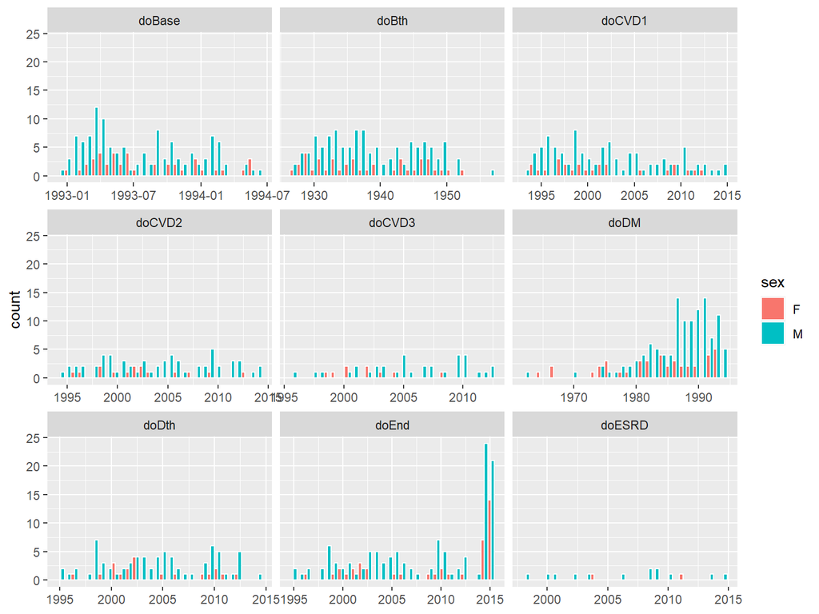

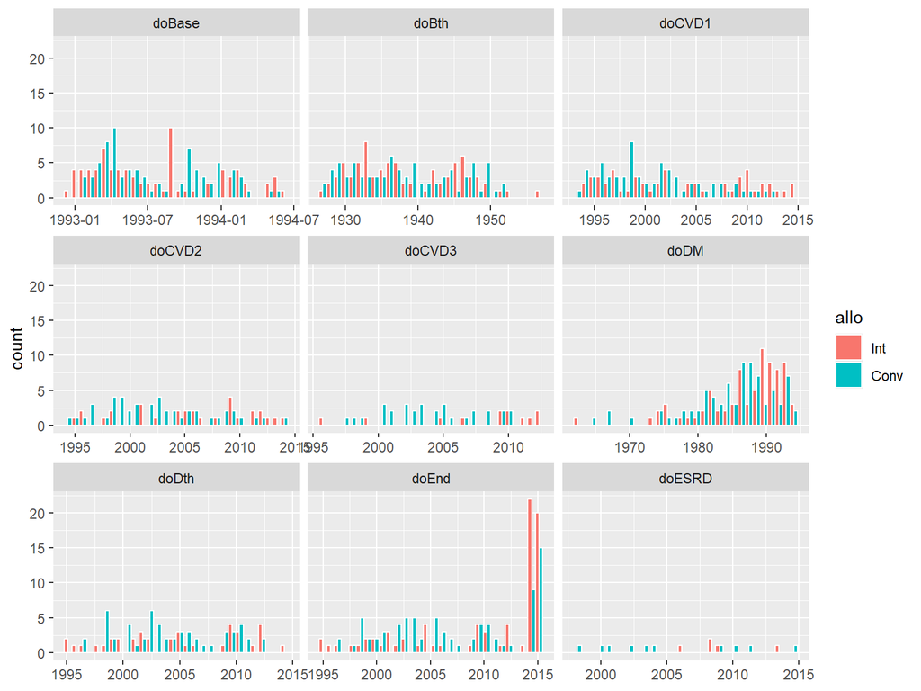

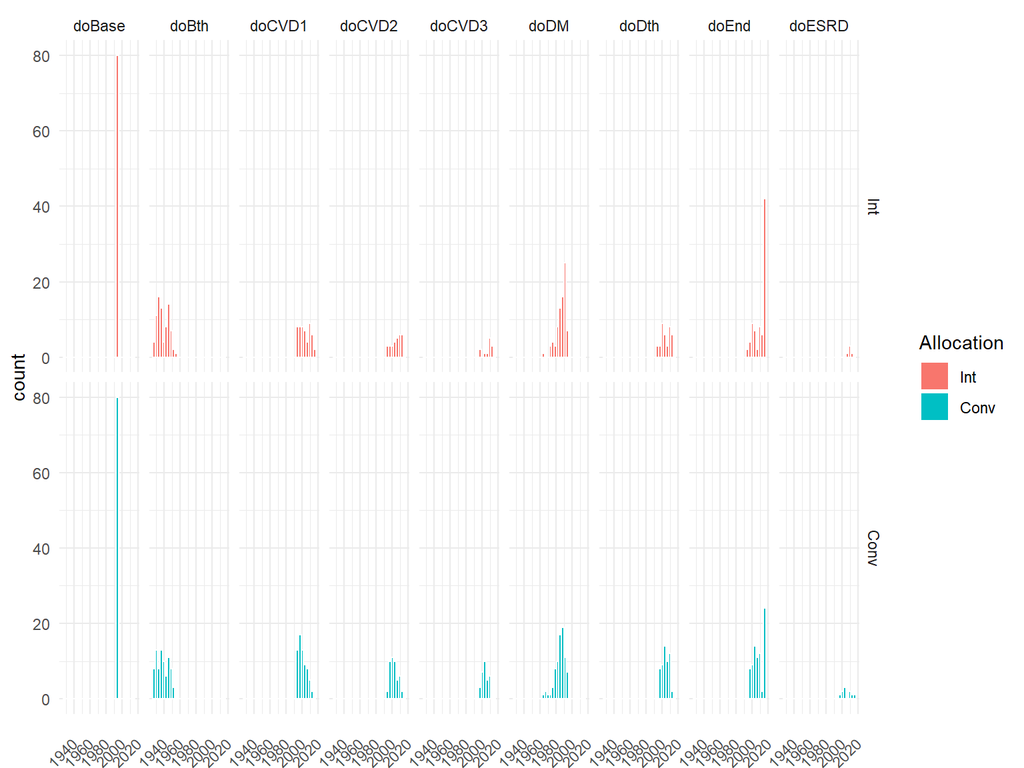

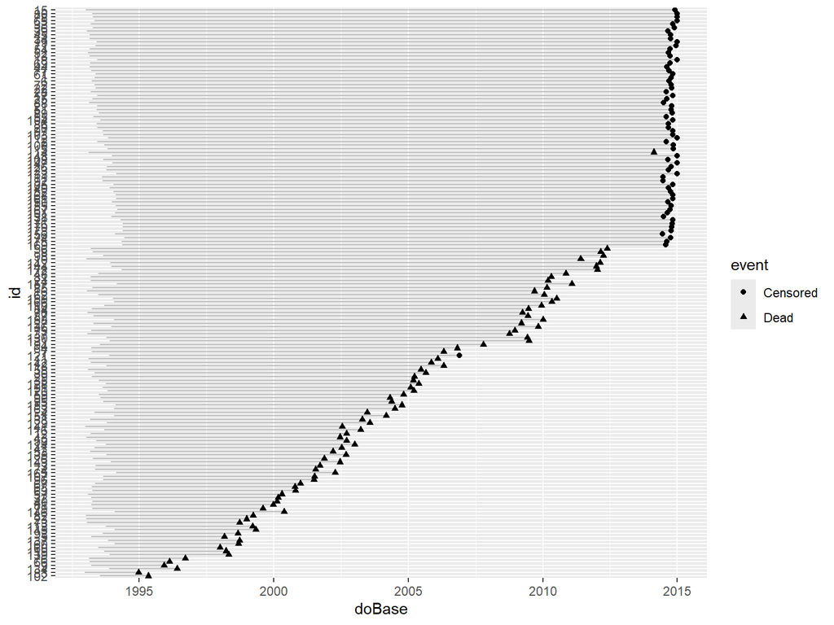

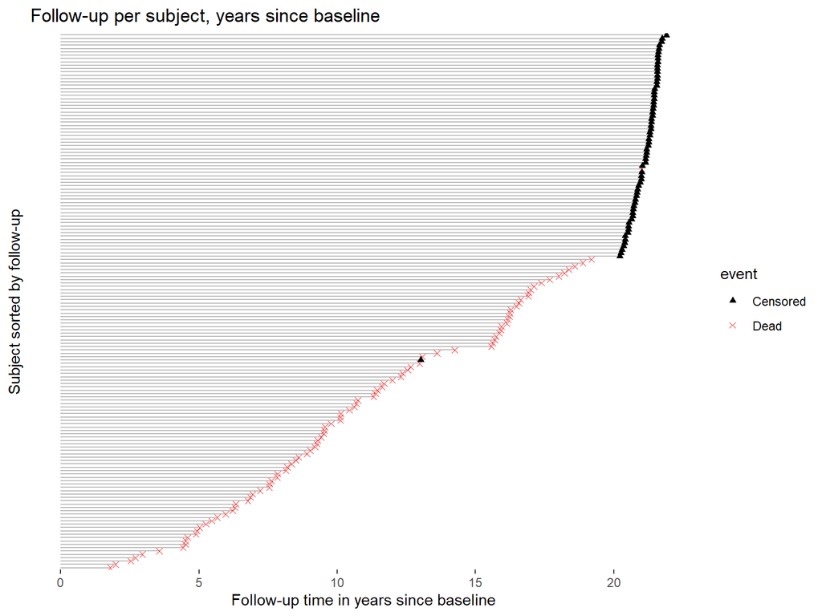

```
Call: survfit(formula = Surv(time_yrs, event_num) ~ 1, data = steno2)

 time n.risk n.event survival std.err lower 95% CI upper 95% CI
    0    160       0    1.000 0.00000        1.000        1.000
    1    160       0    1.000 0.00000        1.000        1.000
    2    158       2    0.988 0.00878        0.970        1.000
    3    155       3    0.969 0.01376        0.942        0.996
    4    154       1    0.963 0.01502        0.934        0.992
    5    148       6    0.925 0.02082        0.885        0.967
    6    143       5    0.894 0.02436        0.847        0.943
    7    137       6    0.856 0.02774        0.804        0.912
    8    131       6    0.819 0.03045        0.761        0.881
    9    125       6    0.781 0.03268        0.720        0.848
   10    116       9    0.725 0.03530        0.659        0.798
Call: survfit(formula = Surv(time_yrs, event_num) ~ allo, data = steno2)
```

[output cut: 116 more lines]

```
[[1]]
Call: survfit(formula = Surv(time_yrs, event_num) ~ 1, data = steno2)

 time n.risk n.event survival std.err lower 95% CI upper 95% CI
    0    160       0    1.000 0.00000        1.000        1.000
    1    160       0    1.000 0.00000        1.000        1.000
    2    158       2    0.988 0.00878        0.970        1.000
    3    155       3    0.969 0.01376        0.942        0.996
    4    154       1    0.963 0.01502        0.934        0.992
    5    148       6    0.925 0.02082        0.885        0.967
    6    143       5    0.894 0.02436        0.847        0.943
    7    137       6    0.856 0.02774        0.804        0.912
    8    131       6    0.819 0.03045        0.761        0.881
    9    125       6    0.781 0.03268        0.720        0.848
   10    116       9    0.725 0.03530        0.659        0.798
```

[output cut: 123 more lines]

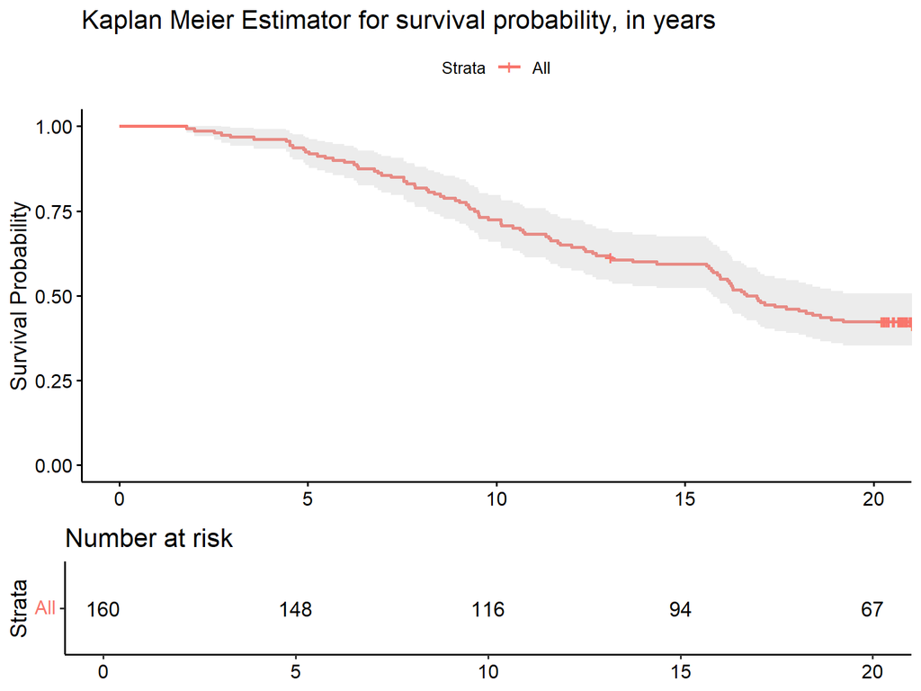

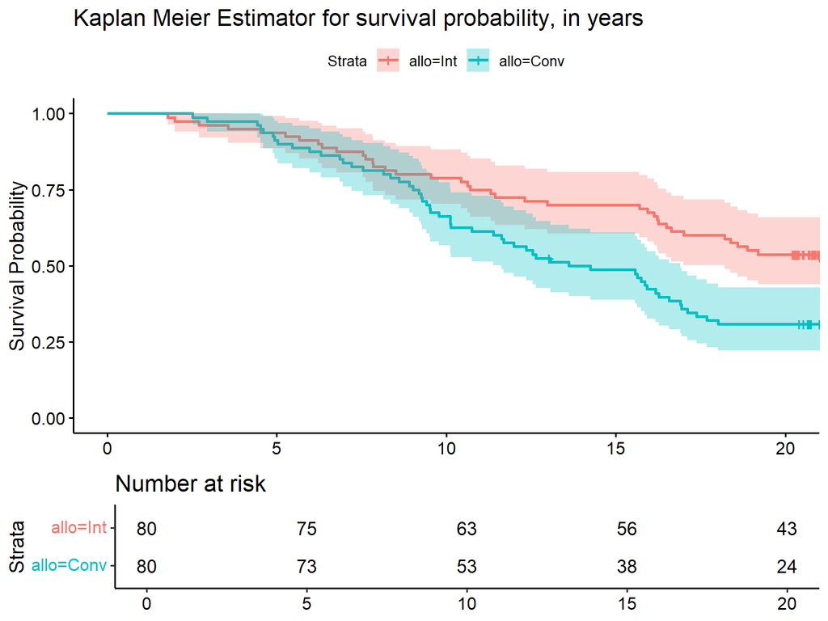

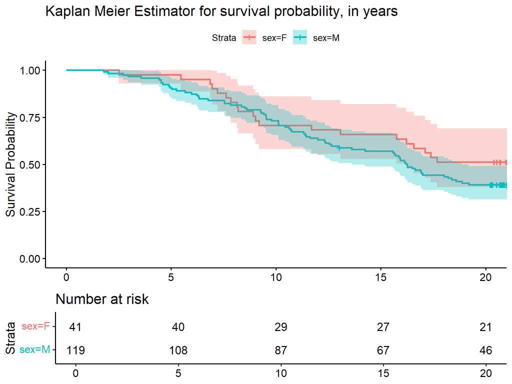

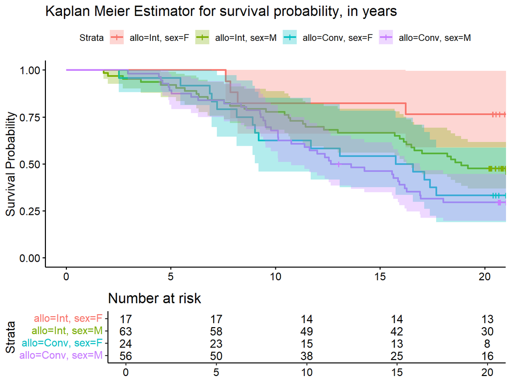